# Taylor Swift

By Rachel

# 1 Introduction

58 Grammy Nominations and 14 Wins. That is the amount of awards Taylor Swift has racked up throughout the years. Being one of the most influential and successful artists of the 21st century, Taylor Swift has written chart-topping songs across multiple genres including country, pop, and indie-folk.

In our project, let’s investigate the main question: How has Taylor Swift’s evolving musical style (in terms of danceability, energy, and valence) correlates with shifts in the themes she explores in her albums?

# 2 Data Description

The data is retrieved from the TidyTuesday project, created by W. Jake Thompson. This taylor dataset is a curated datasets of Taylor Swift songs, from the API of both Spotify, an audio streaming platform and Genius, a digital media company. In this data package, there are 3 different data sets, namely `taylor_album_songs`, `taylor_all_songs` and `taylor_albums`. For this project, I have chosen to focus on the `taylor_all_songs` dataset, which contains 356 songs across 29 variables, offering a rich view of Taylor’s musical output.

# 3 Data Cleaning and Modification

In order to streamline the analysis, I selected seven relevant key columns for the report: album_name, track_name, track_release, danceability, valence, energy, and lyrics. To ensure consistency and remove any potential bias, any tracks labeled as “Taylor’s Version” are also excluded since not all albums were re-released under this new title. Her holiday album is also filtered out since they’re often traditional Christmas songs. The danceability, energy, and valence of these songs are likely not representative of the overall evolution of her original style.

A quick glimpse of the first 6 data give us the following:

```
## # A tibble: 6 × 7
##   album_name   track_name     track_release danceability valence energy lyrics
##   <chr>        <chr>          <date>               <dbl>   <dbl>  <dbl> <list>
## 1 Taylor Swift Tim McGraw     2006-06-19           0.58    0.425  0.491 <tibble>
## 2 Taylor Swift Picture To Bu… 2006-10-24           0.658   0.821  0.877 <tibble>
## 3 Taylor Swift Teardrops On … 2006-10-24           0.621   0.289  0.417 <tibble>
## 4 Taylor Swift A Place In Th… 2006-10-24           0.576   0.428  0.777 <tibble>
## 5 Taylor Swift Cold As You    2006-10-24           0.418   0.261  0.482 <tibble>
## 6 Taylor Swift The Outside    2006-10-24           0.589   0.591  0.805 <tibble>
```

A table of the brief description for the 7 relevant columns after cleaning, is as shown below:

Table 1: Brief Description of the 7 variables

| Variable | Class | Description |
| --- | --- | --- |
| album_name | chr | Album name |
| track_name | chr | Track name |
| track_release | date | Date of track release |
| danceability | dbl | Spotify danceability score. A value of 0.0 is least danceable and 1.0 is most danceable (after scaling). |
| valence | dbl | Spotify valence score. A measure from 0.0 to 1.0 describing the musical positiveness conveyed by a track. Tracks with high valence sound more positive (e.g. happy, cheerful, euphoric), while tracks wi… |
| energy | dbl | Spotify energy score. Energy is a measure from 0.0 to 1.0 and represents a perceptual measure of intensity and activity. |
| lyrics | list | Lyrics in the songs in nested tibbles |

As there will be further analysis on the underlying themes present for each song, each track has to be categorized according to its dominant thematic focus. For this project, 4 popular themes commonly found in music have been identified: 1. *Self-Discovery and Growth* 2. *Heartbreak and Loss* 3. *Love and Romance* 4. *Friendship*.

To assign each song to one of these themes, a set of keywords associated with each category was manually curated. For example, terms like “change” and “reflection” were linked to Self-Discovery and Growth, while words like “cry” and “goodbye” were associated with Heartbreak and Loss.

This thematic classification allows for further investigation of the lyrical content of Taylor Swift’s music and uncover patterns related to her emotions and personal experiences throughout her career.

A quick summary of the number of categorised songs based on the theme is illustrated below:

Table 2: Number of Songs by each Lyrical Theme

| Themes | Number of songs |
| --- | --- |
| Friendship | 15 |
| Self-Discovery and Growth | 34 |
| Love and Romance | 78 |
| Heartbreak and Loss | 84 |

As seen in the table above, Taylor Swift has focused writing many of her songs on HeartBreak and Loss as well as Love and Romance. Such examples include “All Too Well” and “You Belong with Me”.

However, limitations when using such keyword-based approach are acknowledged and hence understand that the categorization may not be the most accurate. This stems from various reasons such as missing out several keywords that could help better define some themes and the ambiguity of certain words which could potentially be in two themes such as “heart”. Furthermore, songwriters such as Taylor Swift love to use figurative languages in her songs and thus the meaning behind certain songs may not be as literal as it may seem. Hence, to further improve on the accuracy, the keyword list is regularly updated.

After preliminary cleaning and modification, I end up with `taylor_songs_clean` dataset which also has 7 variables as before, with only the exception that the lyrics variable has been replaced by lyrical_theme. The first 6 data of `taylor_songs_clean` can be seen below:

```
## # A tibble: 6 × 7
##   album_name  track_name track_release danceability valence energy lyrical_theme
##   <chr>       <chr>      <date>               <dbl>   <dbl>  <dbl> <fct>
## 1 Taylor Swi… Tim McGraw 2006-06-19           0.58    0.425  0.491 Self-Discove…
## 2 Taylor Swi… Picture T… 2006-10-24           0.658   0.821  0.877 Heartbreak a…
## 3 Taylor Swi… Teardrops… 2006-10-24           0.621   0.289  0.417 Love and Rom…
## 4 Taylor Swi… A Place I… 2006-10-24           0.576   0.428  0.777 Self-Discove…
## 5 Taylor Swi… Cold As Y… 2006-10-24           0.418   0.261  0.482 Love and Rom…
## 6 Taylor Swi… The Outsi… 2006-10-24           0.589   0.591  0.805 Self-Discove…
```

# 4 Visualizations

## 4.1 How have the thematic focuses in Taylor Swift’s albums evolved over time?

### 4.1.1 Introduction

Many people claim that Taylor Swift **only** writes breakup songs or songs about her exes. However, is this really the case? Can we use data to debunk this and is she gradually moving away from this theme in her more recent work? Let’s find out more.

### 4.1.2 Methodology

For this analysis where I aimed to explore the distribution of theme across Taylor Swift’s albums, I have decided to first further clean our `taylor_songs_clean` dataset by arranging the albums in chronological order based on release data to maintain a proper timeline, and plot a circular bar plot. The proportions of songs for each album can be seen in the bar plot, which visually represents the distribution of different lyrical themes across Taylor Swift’s discography.

### 4.1.3 Plot

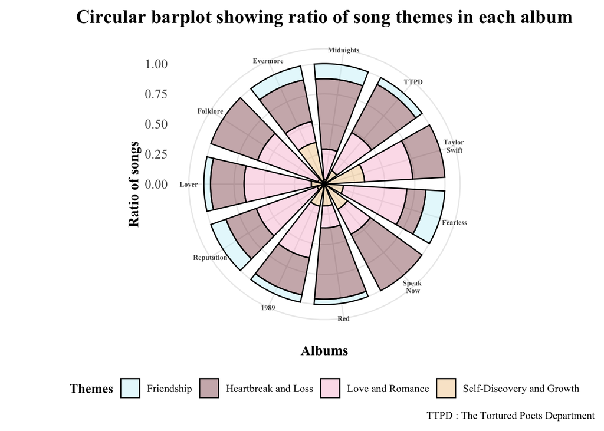

### 4.1.4 Discussion

The circular bar plot reveals that almost all of Taylor Swift’s album features a blend of the four key themes I have explored. Hence, it is definitely not true that Taylor Swift *only* writes about her exes. Yet, it is understandably why most people have this impression since the two predominant themes she writes in most of her albums are about Heartbreak and Loss as well as Love and Romance. This further aligns with the large number of songs in her discography centered around these emotional themes as shown in *Table 2* above. Notably, Speak Now, Red, Midnights, and TTPD contain the highest proportion of songs related to Heartbreak and Loss, which is consistent with the fact that these albums are widely recognized as her “break-up” albums, with well-known breakup songs such as “Dear John” and “Midnight Rain”.

As Taylor is currently in a relationship, I could hypothesize that her future albums may shift towards a more uplifting, “happy lover” theme, possibly incorporating themes of self-discovery and growth. However, only time and data will tell how her songwriting evolves with her personal experiences.

## 4.2 How do musical qualities such as danceability, energy, and valence correspond to the lyrical themes in Taylor Swift’s songs

### 4.2.1 Introduction

Now that we have seen how lyrical themes have evolved in Taylor Swift’s discography, we can look at how musical characteristics vary across the 4 different themes that we have explored.

### 4.2.2 Methodology

For this question, I chose a box plot layered on top of scatter plots for the different themes. With the help of box plots, it helps us to highlight the two different quartiles as well as the median, for easier comparison. However, it is important to note that the datasets for themes like Friendship and Self-Discovery and Growth are relatively smaller, which may limit the accuracy of our measurements for these themes in terms of Taylor Swift’s songwriting.

### 4.2.3 Plot

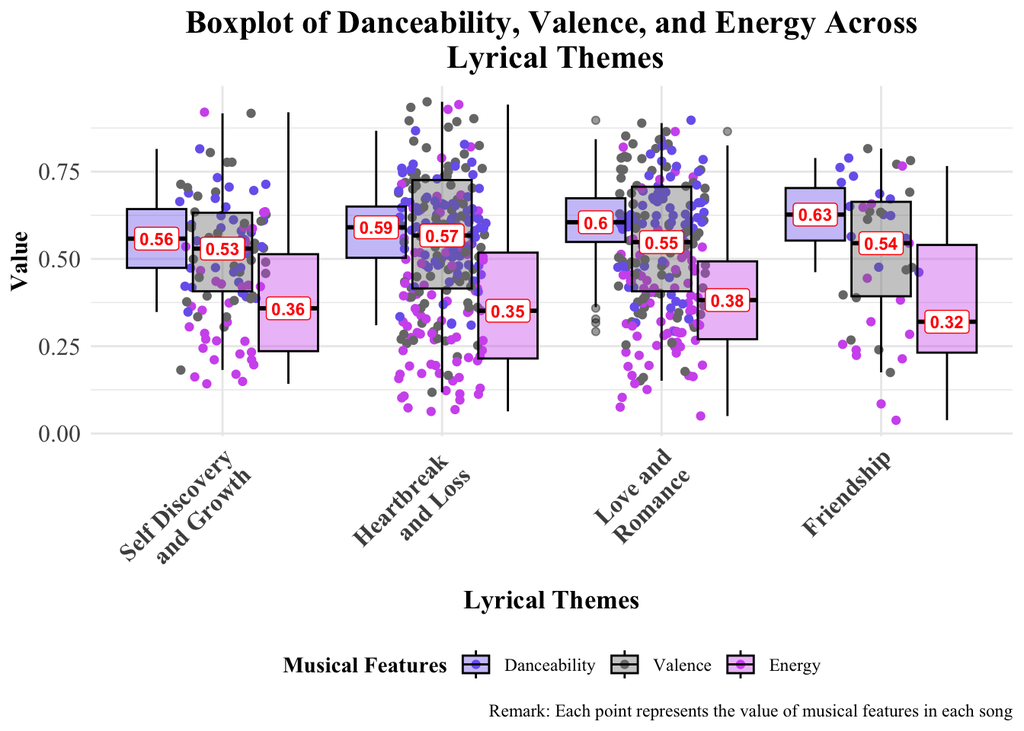

### 4.2.4 Discussion

From the plot, it can be seen that danceability, energy and valence generally follow similar patterns across all themes.

Notably, danceability is most pronounced in songs with positive themes, such as Friendship, which boasts the highest danceability score of 0.63. This aligns with the idea that these themes are often associated with uplifting, feel-good vibes. This suggests that songs focused on positive emotions are typically crafted to encourage movement and evoke a joyful atmosphere.

## 4.3 How do the musical features such as danceability, energy and valence change across albums?

### 4.3.1 Introduction

After learning how the lyrical theme evolve across the albums and how the musical features vary for each theme, let’s combine and take a look at how musical characteristics have therefore evolved across her discography.

### 4.3.2 Methodology

I created a line plot displaying the changes in each musical feature (danceability, energy, valence) across albums. Each feature was assigned a distinct colour, and a dashed line was added to indicate the overall mean value for each characteristic. The plot was also faceted by characteristic to clearly show the evolution of each characteristic separately. The overall mean value for each characteristic across all albums was calculated for comparison, and the albums were ordered according to their release sequence.